# Final Project Analysis Regression

Jason Booth

The first analysis step is to analyze responses to the how_satisfied_are_you_with_your_life_in_general survey question using regression models to see what sorts of factors in the data are statistically significant in determining these scores. Fitting of regression parameters will be used to reduce features in the model to only those which are statistically significant. The model will be assessed in terms of MSE, R-squared, and F-score. This regression will be run on the dataFrames from 2013 and 2015 to see if there are any trends that can be seen over time. Lastly, to add another comparison a dataset from Kaggle which contains the most immportant factors of happiness within countries from around the world will be read in and compared to the results.

Read in the data from CSV files. The ward and precinct files are treated as doubles when read in, so they need to be explicitly converted to factors.

```r
happyData13 <- read.csv("C:\\Users\\Jason\\Documents\\R_Notebooks\\FinalProject\\data\\CleanData\\CleanHappyData13.csv")
happyData15 <- read.csv("C:\\Users\\Jason\\Documents\\R_Notebooks\\FinalProject\\data\\CleanData\\CleanHappyData15.csv")
happyData13$ward <- as.factor(happyData13$ward)
happyData15$ward <- as.factor(happyData15$ward)
happyData13
```

| age | are_you_a_student | children_age_18_or_younger_who_live_with_you | move_away_from_somerville_in_the_next_two_years | how_happy_do_you_feel_right_now | how_long_have_you_lived_here | how_satisfied_are_you_with_somerville_as_a_place_to_live | how_satisfied_are_you_with_the_beauty_or_physical_setting_of_your_neighborhood | how_satisfied_are_you_with_your_life_in_general | how_satisfied_are_you_with_your_neighborhood | availability_of_social_community_events | beauty_or_physical_setting_of_somerville_2013 | cost_of_housing | ward | annual_household_income | sex | how_safe_do_you_feel_walking_in_your_neighborhood_at_night_2013 | how_satisfied_are_you_with_the_appearance_of_parks_in_your_neighborhood_2013 | effectiveness_of_the_local_police_2011_2013 | maintenance_of_streets_sidewalks_and_squares_2013 | race |
| --- | --- | --- | --- | --- | --- | --- | --- | --- | --- | --- | --- | --- | --- | --- | --- | --- | --- | --- | --- | --- |
| 4.000000 | No | Yes | Yes | 10.0 | 7.000000 | 1 | 6.000000 | 10.0 | 10.0 | 6.000000 | 6 | 10.000000 | 2 | 7.000 | Male | 10.000000 | 8.000000 | 10.000000 | 8.000000 | White |
| 2.000000 | No | No | Yes | 3.0 | 5.000000 | 7 | 6.000000 | 2.0 | 6.0 | 8.000000 | 6 | 4.000000 | 5 | 4.000 | Female | 7.000000 | 6.000000 | 8.000000 | 6.000000 | White |
| 3.000000 | No | Yes | Yes | 8.0 | 3.000000 | 8 | 5.000000 | 8.0 | 8.0 | 8.000000 | 6 | 10.000000 | 5 | 4.000 | Male | 9.000000 | 4.000000 | 10.000000 | 6.000000 | Asian/Pacific Islander |
| 5.000000 | No | No | No | 6.0 | 7.000000 | 1 | 3.000000 | 6.0 | 5.0 | 8.000000 | 6 | 6.000000 | 1 | 1.000 | Female | 4.000000 | 8.000000 | 6.000000 | 4.000000 | White |
| 4.000000 | No | Yes | Yes | 5.0 | 5.000000 | 5 | 5.000000 | 5.0 | 5.0 | 6.000000 | 8 | 6.000000 | 1 | 3.000 | Female | 5.000000 | 6.000000 | 6.000000 | 6.000000 | Black/African American |
| 2.000000 | No | No | No | 8.0 | 1.000000 | 8 | 6.000000 | 8.0 | 6.0 | 10.000000 | 8 | 6.000000 | 5 | 5.000 | Female | 6.000000 | 6.000000 | 8.000000 | 8.000000 | White |
| 3.000000 | No | No | No | 9.0 | 3.000000 | 8 | 8.500000 | 9.0 | 8.5 | 8.043478 | 10 | 8.000000 | 3 | 2.000 | Male | 9.000000 | 9.000000 | 8.000000 | 8.000000 | Asian/Pacific Islander |
| 3.650794 | No | No | No | 10.0 | 1.000000 | 9 | 8.000000 | 10.0 | 9.0 | 8.000000 | 8 | 8.000000 | 2 | 3.975 | Female | 8.000000 | 8.000000 | 7.778378 | 6.000000 | Asian/Pacific Islander |
| 6.000000 | No | No | No | 5.5 | 7.000000 | 8 | 7.000000 | 3.0 | 8.0 | 8.000000 | 6 | 6.000000 | 3 | 3.000 | Female | 7.000000 | 8.000000 | 6.000000 | 4.000000 | Asian/Pacific Islander |
| 2.000000 | No | No | No | 8.0 | 3.000000 | 8 | 6.000000 | 8.0 | 8.0 | 9.000000 | 8 | 6.000000 | 5 | 4.000 | Female | 7.000000 | 6.000000 | 6.000000 | 4.000000 | White |

[output cut: 183 more lines]

```r
happyData15
```

| age | are_you_a_student | housing_status_in_somerville | children_age_18_or_younger_who_live_with_you | move_away_from_somerville_in_the_next_two_years | how_happy_do_you_feel_right_now | how_long_have_you_lived_here | how_proud_are_you_to_be_a_somerville_resident_2015 | how_safe_do_you_feel_walking_in_your_community_at_night_2015 | how_satisfied_are_you_with_somerville_as_a_place_to_live | how_satisfied_are_you_with_the_appearance_of_parks_and_squares_in_your_neighborhood | how_satisfied_are_you_with_the_beauty_or_physical_setting_of_your_neighborhood | how_satisfied_are_you_with_your_life_in_general | how_satisfied_are_you_with_your_neighborhood | availability_of_information_about_city_services_2015 | availability_of_social_community_events | cost_of_housing | maintenance_of_streets_and_sidewalks_2015 | how_would_you_rate_the_following_your_trust_in_the_local_police_2015 | ward | annual_household_income | sex | race |
| --- | --- | --- | --- | --- | --- | --- | --- | --- | --- | --- | --- | --- | --- | --- | --- | --- | --- | --- | --- | --- | --- | --- |
| 3.000000 | No | Rent | No | No | 7.000000 | 3.000000 | 9.000000 | 8.000000 | 7 | 4.000000 | 3.000000 | 5.000000 | 5 | 6.000000 | 6.000000 | 4.000000 | 2.000000 | 4.000000 | 4 | 6.000000 | Male | Mixed |
| 2.000000 | Yes | Rent | No | Yes | 8.000000 | 2.000000 | 7.000000 | 8.000000 | 7 | 8.000000 | 7.000000 | 8.000000 | 8 | 6.000000 | 8.000000 | 6.000000 | 4.000000 | 8.000000 | 7 | 3.000000 | Female | White |
| 6.000000 | No | Rent | No | No | 5.000000 | 7.000000 | 5.000000 | 7.000000 | 6 | 7.000000 | 7.000000 | 9.000000 | 7 | 6.000000 | 6.000000 | 4.000000 | 8.000000 | 10.000000 | 3 | 3.000000 | Male | White |
| 5.000000 | No | Own | No | No | 5.000000 | 6.000000 | 9.000000 | 9.000000 | 9 | 8.000000 | 8.000000 | 8.000000 | 9 | 10.000000 | 10.000000 | 6.000000 | 6.000000 | 6.000000 | 3 | 4.770701 | Female | White |
| 2.000000 | No | Own | Yes | No | 7.000000 | 3.000000 | 7.000000 | 9.000000 | 8 | 7.000000 | 7.000000 | 9.000000 | 7 | 10.000000 | 10.000000 | 8.000000 | 6.000000 | 6.000000 | 5 | 7.000000 | Male | White |
| 2.000000 | Yes | Rent | No | No | 7.000000 | 2.000000 | 8.000000 | 7.000000 | 9 | 7.000000 | 8.000000 | 8.000000 | 9 | 10.000000 | 10.000000 | 6.000000 | 8.000000 | 6.000000 | 7 | 2.000000 | Female | White |
| 5.000000 | No | Own | No | No | 10.000000 | 7.000000 | 10.000000 | 10.000000 | 10 | 10.000000 | 10.000000 | 10.000000 | 10 | 10.000000 | 10.000000 | 10.000000 | 10.000000 | 10.000000 | 3 | 7.000000 | Male | White |
| 5.000000 | No | Own | No | No | 7.000000 | 6.000000 | 7.000000 | 4.000000 | 8 | 4.000000 | 2.000000 | 8.000000 | 4 | 6.000000 | 6.000000 | 2.000000 | 2.000000 | 4.000000 | 1 | 5.000000 | Female | White |
| 2.000000 | No | Rent | No | No | 8.000000 | 3.000000 | 9.000000 | 9.000000 | 9 | 10.000000 | 9.000000 | 8.000000 | 9 | 10.000000 | 10.000000 | 8.000000 | 8.000000 | 8.000000 | 3 | 4.770701 | Male | White |
| 3.000000 | No | Rent | No | No | 7.000000 | 3.000000 | 5.000000 | 9.000000 | 7 | 9.000000 | 8.000000 | 8.000000 | 7 | 8.000000 | 8.000000 | 2.000000 | 8.000000 | 8.000000 | 6 | 7.000000 | Male | White |

[output cut: 175 more lines]

The surveys for 2013 and 2015 are more similar to each other than with the survey from 2011. Using the intersect function below there are 16 overlapping categories. We’ll only use only these features in the multiple regression so that we can compare the two surveys.

```r
commonCols <- intersect(colnames(happyData13), colnames(happyData15))
happyData13Common <- subset(happyData13, select = commonCols)
happyData15Common <- subset(happyData15, select = commonCols)
commonCols
```

```
 [1] "age"
 [2] "are_you_a_student"
 [3] "children_age_18_or_younger_who_live_with_you"
 [4] "move_away_from_somerville_in_the_next_two_years"
 [5] "how_happy_do_you_feel_right_now"
 [6] "how_long_have_you_lived_here"
 [7] "how_satisfied_are_you_with_somerville_as_a_place_to_live"
 [8] "how_satisfied_are_you_with_the_beauty_or_physical_setting_of_your_neighborhood"
 [9] "how_satisfied_are_you_with_your_life_in_general"
[10] "how_satisfied_are_you_with_your_neighborhood"
[11] "availability_of_social_community_events"
[12] "cost_of_housing"
[13] "ward"
[14] "annual_household_income"
[15] "sex"
[16] "race"
```

Use the pairs.panels function from the psych package to plot the data and to see if there are any correlations between variables before running the model. Multiple regression assumes that there is no strong correlation between features because this can cause a situation where the significance of a variable is shared between two features. how_satisfied_are_you_with_your_life_in_general is removed from the pairs.panels analysis because that is the feature we are performing the regression on.

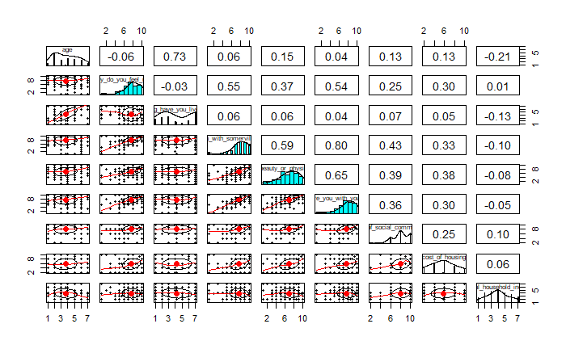

```r
# Commented out for the graders convenience
# install.packages("psych")
library(psych)
happyData13NumericFeatures <- happyData13Common[,which(sapply(happyData13Common, is.numeric) == TRUE)]
happyData13NumericFeatures <- subset(happyData13NumericFeatures, select=-c(how_satisfied_are_you_with_your_life_in_general))
pairs.panels(happyData13NumericFeatures)
```

There appears to be a correlation that exists for the column how_long_have_you_lived_here. An exploratory plot is used to determine its distribution. It is found not to be normal, which is another assumption of multiple regression, so this feature will not be used in the analysis. However, for the sake of exploraion, average responses by length of time spent in somerville is presented below. It does not appear to be statistically significant in determining the responses of the satisfaction and happiness questions.

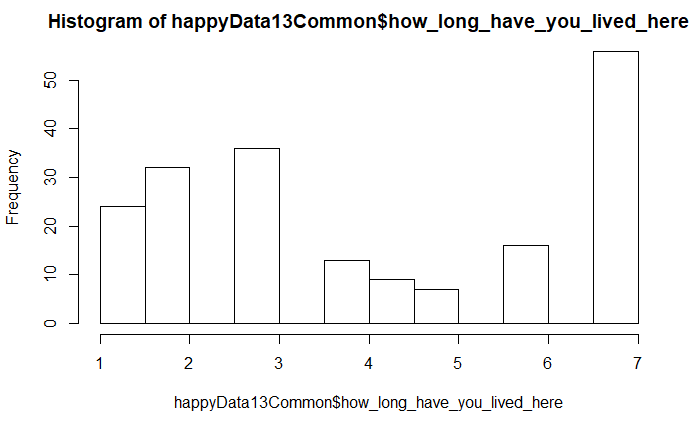

```r
hist(happyData13Common$how_long_have_you_lived_here)
```

```r
aggregate(how_satisfied_are_you_with_your_life_in_general ~ how_long_have_you_lived_here, happyData13Common, mean)
```

| how_long_have_you_lived_here | how_satisfied_are_you_with_your_life_in_general |
| --- | --- |
| 1.000000 | 7.791667 |
| 2.000000 | 8.156250 |
| 3.000000 | 7.861111 |
| 4.000000 | 5.846154 |
| 4.190217 | 6.000000 |
| 5.000000 | 6.571429 |
| 6.000000 | 7.968750 |
| 7.000000 | 8.267857 |

```r
happyData13Common <- subset(happyData13Common, select=-c(how_long_have_you_lived_here))
happyData13NumericFeatures <- subset(happyData13NumericFeatures, select=-c(how_long_have_you_lived_here))
```

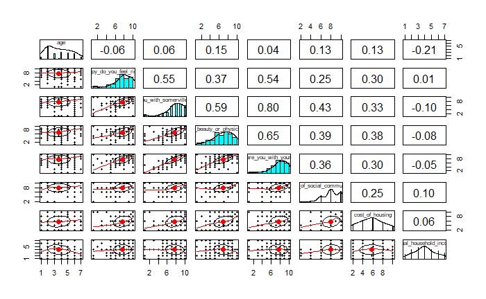

```r
pairs.panels(happyData13NumericFeatures)
```

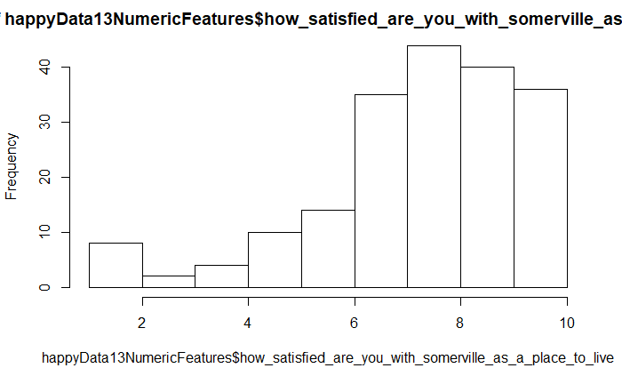

```r
hist(happyData13NumericFeatures$how_satisfied_are_you_with_somerville_as_a_place_to_live)
```

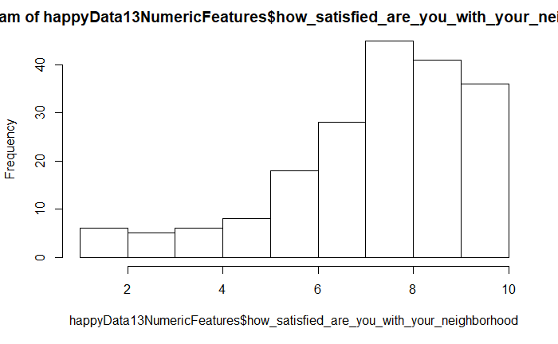

```r
hist(happyData13NumericFeatures$how_satisfied_are_you_with_your_neighborhood)
```

```r
cor(happyData13NumericFeatures$how_satisfied_are_you_with_somerville_as_a_place_to_live, happyData13NumericFeatures$how_satisfied_are_you_with_your_neighborhood)
```

```
[1] 0.8044589
```

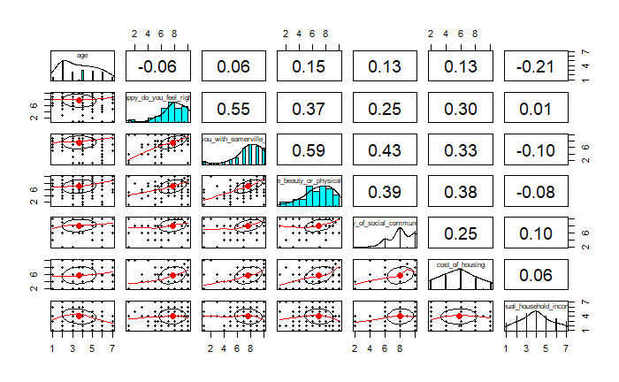

```r
happyData13NumericFeatures <- subset(happyData13NumericFeatures, select = -c(how_satisfied_are_you_with_your_neighborhood))
happyData13Common <- subset(happyData13Common, select = -c(how_satisfied_are_you_with_your_neighborhood))
pairs.panels(happyData13NumericFeatures)
```

A model is created fitting all available features. The results of the regression show that the coefficient of several features are not significantly statistically different from 0. The features should be downselected and the regression should be run again.

```r
fit13AllHappy <- lm(how_satisfied_are_you_with_your_life_in_general ~ ., happyData13Common)
summary(fit13AllHappy)
```

```
Call:
lm(formula = how_satisfied_are_you_with_your_life_in_general ~
    ., data = happyData13Common)

Residuals:
    Min      1Q  Median      3Q     Max
-6.5698 -0.5491  0.0654  0.6880  5.5496

Coefficients:
                                                                                Estimate Std. Error t value Pr(>|t|)
(Intercept)                                                                     1.304925   0.748828   1.743  0.08320 .
age                                                                             0.024346   0.066101   0.368  0.71309
are_you_a_studentYes                                                            0.191636   0.367903   0.521  0.60312
children_age_18_or_younger_who_live_with_youYes                                -0.185036   0.272200  -0.680  0.49756
move_away_from_somerville_in_the_next_two_yearsYes                             -0.317717   0.249497  -1.273  0.20459
how_happy_do_you_feel_right_now                                                 0.608006   0.056977  10.671  < 2e-16 ***
how_satisfied_are_you_with_somerville_as_a_place_to_live                        0.065493   0.070053   0.935  0.35115
how_satisfied_are_you_with_the_beauty_or_physical_setting_of_your_neighborhood -0.049643   0.061574  -0.806  0.42123
availability_of_social_community_events                                        -0.001522   0.068031  -0.022  0.98218
cost_of_housing                                                                 0.155388   0.046733   3.325  0.00108 **
ward2                                                                          -0.429973   0.400565  -1.073  0.28460
ward3                                                                          -0.238160   0.408731  -0.583  0.56088
ward4                                                                           0.497308   0.408633   1.217  0.22528
ward5                                                                          -0.773409   0.403631  -1.916  0.05702 .
ward6                                                                           0.248201   0.394869   0.629  0.53047
ward7                                                                           0.008378   0.441109   0.019  0.98487
annual_household_income                                                         0.129042   0.065714   1.964  0.05119 .
sexMale                                                                         0.311755   0.203627   1.531  0.12762
raceBlack/African American                                                      1.088476   0.761958   1.429  0.15497
raceMixed                                                                       0.177128   0.431858   0.410  0.68221
raceNative American                                                             2.622572   1.406805   1.864  0.06401 .
raceWhite                                                                       0.229067   0.331783   0.690  0.49087
---
Signif. codes:  0 *** 0.001 ** 0.01 * 0.05 . 0.1   1

Residual standard error: 1.301 on 171 degrees of freedom
Multiple R-squared:  0.6054,    Adjusted R-squared:  0.5569
F-statistic: 12.49 on 21 and 171 DF,  p-value: < 2.2e-16
```

In the process of iteratively down-selecting to only statistically significant features, race was removed. The remaining features show that how_happy_do_you_feel_right_now and cost_of_housing have positive effects on the satisfaction level, while living in ward 5 have a negative effect. Also, annual_household_income was shown to have a positive impact, although this impact is not considered statistically significant.

```r
fit13SigHappy <- lm(how_satisfied_are_you_with_your_life_in_general ~ how_happy_do_you_feel_right_now + how_satisfied_are_you_with_the_beauty_or_physical_setting_of_your_neighborhood + cost_of_housing + ward + annual_household_income, happyData13Common)
summary(fit13SigHappy)
```

```
Call:
lm(formula = how_satisfied_are_you_with_your_life_in_general ~
    how_happy_do_you_feel_right_now + how_satisfied_are_you_with_the_beauty_or_physical_setting_of_your_neighborhood +
        cost_of_housing + ward + annual_household_income, data = happyData13Common)

Residuals:
    Min      1Q  Median      3Q     Max
-6.6280 -0.5857  0.0199  0.7202  5.8207

Coefficients:
                                                                                Estimate Std. Error t value Pr(>|t|)
(Intercept)                                                                     1.794680   0.498669   3.599 0.000412 ***
how_happy_do_you_feel_right_now                                                 0.617462   0.050556  12.213  < 2e-16 ***
how_satisfied_are_you_with_the_beauty_or_physical_setting_of_your_neighborhood  0.012886   0.052592   0.245 0.806723
cost_of_housing                                                                 0.152947   0.044872   3.408 0.000804 ***
ward2                                                                          -0.466101   0.377223  -1.236 0.218196
ward3                                                                          -0.365914   0.390286  -0.938 0.349717
ward4                                                                           0.513457   0.390081   1.316 0.189735
ward5                                                                          -0.884870   0.389787  -2.270 0.024371 *
ward6                                                                           0.108452   0.374313   0.290 0.772347
ward7                                                                           0.002305   0.418760   0.006 0.995615
annual_household_income                                                         0.108826   0.061775   1.762 0.079805 .
---
Signif. codes:  0 *** 0.001 ** 0.01 * 0.05 . 0.1   1

Residual standard error: 1.305 on 182 degrees of freedom
Multiple R-squared:  0.5771,    Adjusted R-squared:  0.5538
F-statistic: 24.83 on 10 and 182 DF,  p-value: < 2.2e-16
```

This process is repeated for the data from 2015.

Similar to above, the how_long_have_you_lived_here column does not appear normal and is correlated with other values. It is removed from the features dataframe.

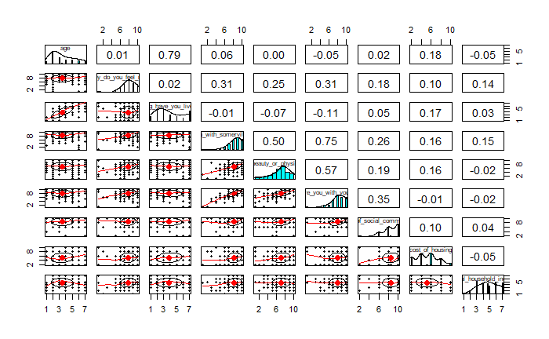

```r
happyData15NumericFeatures <- happyData15Common[,which(sapply(happyData15Common, is.numeric) == TRUE)]
happyData15NumericFeatures <- subset(happyData15NumericFeatures, select=-c(how_satisfied_are_you_with_your_life_in_general))
pairs.panels(happyData15NumericFeatures)
```

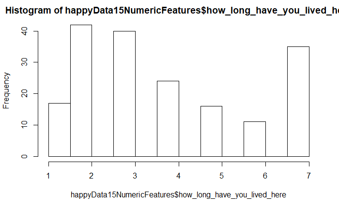

```r
hist(happyData15NumericFeatures$how_long_have_you_lived_here)
```

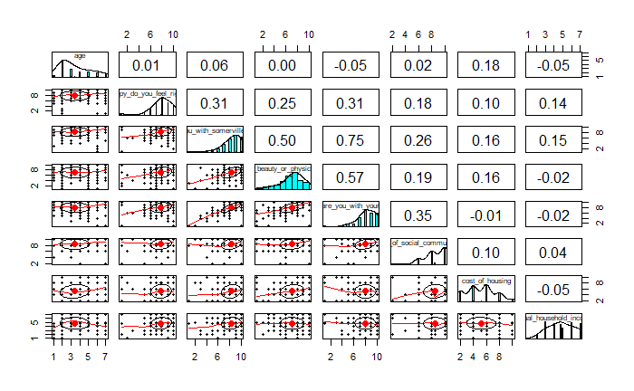

```r
happyData15Common <- subset(happyData15Common, select=-c(how_long_have_you_lived_here))
happyData15NumericFeatures <- subset(happyData15NumericFeatures, select=-c(how_long_have_you_lived_here))
pairs.panels(happyData15NumericFeatures)
```

Correlation still exists between the two features how_satisfied_are_you_with_somerville_as_a_place_to_live and how_satisfied_are_you_with_your_neighborhood with a correlation of .75. Again, how_satisfied_are_you_with_your_neighborhood is removed.

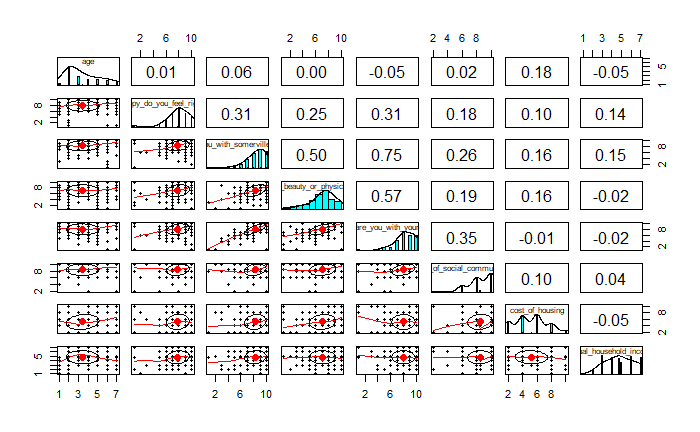

```r
pairs.panels(happyData15NumericFeatures)
```

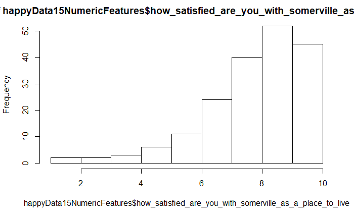

```r
hist(happyData15NumericFeatures$how_satisfied_are_you_with_somerville_as_a_place_to_live)
```

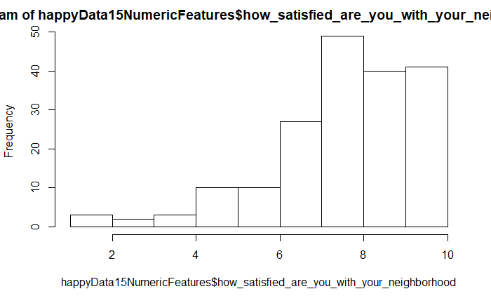

```r
hist(happyData15NumericFeatures$how_satisfied_are_you_with_your_neighborhood)
```

```r
cor(happyData15NumericFeatures$how_satisfied_are_you_with_somerville_as_a_place_to_live, happyData15NumericFeatures$how_satisfied_are_you_with_your_neighborhood)
```

```
[1] 0.7476989
```

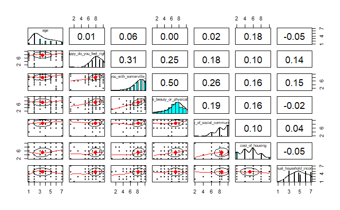

```r
happyData15NumericFeatures <- subset(happyData15NumericFeatures, select = -c(how_satisfied_are_you_with_your_neighborhood))
happyData15Common <- subset(happyData15Common, select = -c(how_satisfied_are_you_with_your_neighborhood))
pairs.panels(happyData15NumericFeatures)
```

A linear model with all features is fit.

```r
happyData15Common
```

|  | age | are_you_a_student | children_age_18_or_younger_who_live_with_you | move_away_from_somerville_in_the_next_two_years | how_happy_do_you_feel_right_now | how_satisfied_are_you_with_somerville_as_a_place_to_live | how_satisfied_are_you_with_the_beauty_or_physical_setting_of_your_neighborhood | how_satisfied_are_you_with_your_life_in_general | availability_of_social_community_events | cost_of_housing | ward | annual_household_income | sex | race |
| --- | --- | --- | --- | --- | --- | --- | --- | --- | --- | --- | --- | --- | --- | --- |
| 1 | 3.000000 | No | No | No | 7.000000 | 7 | 3.000000 | 5.000000 | 6.000000 | 4.000000 | 4 | 6.000000 | Male | Mixed |
| 2 | 2.000000 | Yes | No | Yes | 8.000000 | 7 | 7.000000 | 8.000000 | 8.000000 | 6.000000 | 7 | 3.000000 | Female | White |
| 3 | 6.000000 | No | No | No | 5.000000 | 6 | 7.000000 | 9.000000 | 6.000000 | 4.000000 | 3 | 3.000000 | Male | White |
| 4 | 5.000000 | No | No | No | 5.000000 | 9 | 8.000000 | 8.000000 | 10.000000 | 6.000000 | 3 | 4.770701 | Female | White |
| 5 | 2.000000 | No | Yes | No | 7.000000 | 8 | 7.000000 | 9.000000 | 10.000000 | 8.000000 | 5 | 7.000000 | Male | White |
| 6 | 2.000000 | Yes | No | No | 7.000000 | 9 | 8.000000 | 8.000000 | 10.000000 | 6.000000 | 7 | 2.000000 | Female | White |
| 7 | 5.000000 | No | No | No | 10.000000 | 10 | 10.000000 | 10.000000 | 10.000000 | 10.000000 | 3 | 7.000000 | Male | White |
| 8 | 5.000000 | No | No | No | 7.000000 | 8 | 2.000000 | 8.000000 | 6.000000 | 2.000000 | 1 | 5.000000 | Female | White |
| 9 | 2.000000 | No | No | No | 8.000000 | 9 | 9.000000 | 8.000000 | 10.000000 | 8.000000 | 3 | 4.770701 | Male | White |
| 10 | 3.000000 | No | No | No | 7.000000 | 7 | 8.000000 | 8.000000 | 8.000000 | 2.000000 | 6 | 7.000000 | Male | White |

[output cut: 175 more lines]

```r
fit15AllHappy <- lm(how_satisfied_are_you_with_your_life_in_general ~ ., happyData15Common)
summary(fit15AllHappy)
```

```
Call:
lm(formula = how_satisfied_are_you_with_your_life_in_general ~
    ., data = happyData15Common)

Residuals:
    Min      1Q  Median      3Q     Max
-2.6980 -0.5519  0.0379  0.5368  5.5387

Coefficients:
                                                                                Estimate Std. Error t value Pr(>|t|)
(Intercept)                                                                     3.550770   0.868883   4.087 6.87e-05 ***
age                                                                             0.130452   0.053375   2.444   0.0156 *
are_you_a_studentYes                                                            0.662786   0.312769   2.119   0.0356 *
children_age_18_or_younger_who_live_with_youYes                                -0.056154   0.255011  -0.220   0.8260
move_away_from_somerville_in_the_next_two_yearsYes                              0.047516   0.228013   0.208   0.8352
how_happy_do_you_feel_right_now                                                 0.583772   0.051355  11.367  < 2e-16 ***
how_satisfied_are_you_with_somerville_as_a_place_to_live                       -0.004899   0.065806  -0.074   0.9407
how_satisfied_are_you_with_the_beauty_or_physical_setting_of_your_neighborhood  0.026981   0.053715   0.502   0.6161
availability_of_social_community_events                                        -0.073587   0.054096  -1.360   0.1756
cost_of_housing                                                                 0.023835   0.039439   0.604   0.5465
ward2                                                                          -0.118962   0.405027  -0.294   0.7694
ward3                                                                           0.001868   0.383535   0.005   0.9961
ward4                                                                          -0.297714   0.432800  -0.688   0.4925
ward5                                                                          -0.066289   0.391772  -0.169   0.8658
ward6                                                                           0.140659   0.430985   0.326   0.7446
ward7                                                                           0.013555   0.418281   0.032   0.9742
annual_household_income                                                         0.067881   0.062596   1.084   0.2798
sexFemale, Male                                                                -0.134068   1.203716  -0.111   0.9115
sexMale                                                                        -0.404073   0.196652  -2.055   0.0415 *
raceBlack/African American                                                     -0.994282   0.662098  -1.502   0.1351
raceHispanic / Latino                                                          -0.175631   0.561471  -0.313   0.7548
raceMixed                                                                      -0.690600   0.440222  -1.569   0.1187
raceWhite                                                                      -0.364217   0.339344  -1.073   0.2847
---
Signif. codes:  0 *** 0.001 ** 0.01 * 0.05 . 0.1   1

Residual standard error: 1.133 on 162 degrees of freedom
Multiple R-squared:  0.5435,    Adjusted R-squared:  0.4815
F-statistic: 8.768 on 22 and 162 DF,  p-value: < 2.2e-16
```

After downselection it was found that age, being a student, and how_happy_do_you_feel_right_now had positive effects on the satisfaction score. Being a male had a negative effect. Being African American or Mixed also had a negative effect, although it is not considered statistically significant.

```r
mode(happyData15Common$ward)
```

```
[1] "numeric"
```

```r
fit15SigHappy <- lm(how_satisfied_are_you_with_your_life_in_general ~ age + are_you_a_student + how_happy_do_you_feel_right_now + sex + race, happyData15Common)
summary(fit15SigHappy)
```

```
Call:
lm(formula = how_satisfied_are_you_with_your_life_in_general ~
    age + are_you_a_student + how_happy_do_you_feel_right_now +
        sex + race, data = happyData15Common)

Residuals:
    Min      1Q  Median      3Q     Max
-2.8099 -0.5745  0.0268  0.4830  5.5618

Coefficients:
                                Estimate Std. Error t value Pr(>|t|)
(Intercept)                      3.47168    0.55267   6.282 2.57e-09 ***
age                              0.13293    0.04968   2.676  0.00816 **
are_you_a_studentYes             0.73665    0.29235   2.520  0.01264 *
how_happy_do_you_feel_right_now  0.58917    0.04661  12.641  < 2e-16 ***
sexFemale, Male                  0.15669    1.14787   0.137  0.89158
sexMale                         -0.36143    0.18187  -1.987  0.04845 *
raceBlack/African American      -1.05516    0.58106  -1.816  0.07109 .
raceHispanic / Latino           -0.36412    0.51588  -0.706  0.48124
raceMixed                       -0.74053    0.41341  -1.791  0.07497 .
raceWhite                       -0.42021    0.31965  -1.315  0.19037
---
Signif. codes:  0 *** 0.001 ** 0.01 * 0.05 . 0.1   1

Residual standard error: 1.109 on 175 degrees of freedom
Multiple R-squared:  0.5272,    Adjusted R-squared:  0.5029
F-statistic: 21.69 on 9 and 175 DF,  p-value: < 2.2e-16
```

Comparing the fit of the two models:

These models are using different data so it would be inappropriate to compare them directly. But we can use MSE to see if they are a good fit for the model. Looking at the output of linear regression we see the p-values p-value: < 2.2e-16 p-value: < 2.2e-16 showing that the models are extremely statistically significant and there are relationships between variables. Calculating the MSE below can help us compare the spread of values around the correlation line.

```r
mean(fit13SigHappy$residuals^2)
```

```
[1] 1.606414
```

```r
mean(fit15SigHappy$residuals^2)
```

```
[1] 1.16327
```

Because the MSE is slightly higher for the first model, we can conclude that the interval of prediction will likely contain more variance that the model from 2015. Although it can’t be seen explicitly, the confidence intervals for each feature below.

```r
confint(fit13SigHappy)
```

```
                                                                                     2.5 %     97.5 %
(Intercept)                                                                     0.81076338  2.7785966
how_happy_do_you_feel_right_now                                                 0.51771028  0.7172147
how_satisfied_are_you_with_the_beauty_or_physical_setting_of_your_neighborhood -0.09088195  0.1166531
cost_of_housing                                                                 0.06441018  0.2414845
ward2                                                                          -1.21039384  0.2781918
ward3                                                                          -1.13598164  0.4041535
ward4                                                                          -0.25620652  1.2831199
ward5                                                                          -1.65395220 -0.1157879
ward6                                                                          -0.63009797  0.8470024
ward7                                                                          -0.82394437  0.8285540
annual_household_income                                                        -0.01306017  0.2307127
```

```r
confint(fit15SigHappy)
```

```
                                     2.5 %       97.5 %
(Intercept)                      2.3809205  4.562441123
age                              0.0348835  0.230972394
are_you_a_studentYes             0.1596714  1.313625035
how_happy_do_you_feel_right_now  0.4971838  0.681159968
sexFemale, Male                 -2.1087551  2.422143599
sexMale                         -0.7203836 -0.002482305
raceBlack/African American      -2.2019354  0.091623544
raceHispanic / Latino           -1.3822769  0.654037196
raceMixed                       -1.5564401  0.075372306
raceWhite                       -1.0510667  0.210652472
```

As a last exercise, another dataset from kaggle is pulled in and analyzed briefly. This dataset is from a worldwide census on happiness data. It consists of a list of countries and a list of factors questioned about in the survey. Each factor has a value corresponding to the significance of that value on the happiness of the country. To get a sense of the most important factors, I summed over each of the columns across all countries, and the converted each column’s sum into a percentage of the total summation. This results in a percentage for how important each column is across countries.

```r
worldData <- read.csv("C:\\Users\\Jason\\Documents\\R_Notebooks\\FinalProject\\data\\WorldHappiness\\2015.csv")
contributingFactorColumns <- c("Economy..GDP.per.Capita.", "Family", "Health..Life.Expectancy.", "Freedom", "Trust..Government.Corruption.", "Generosity")
columnSignificance <- sort(colSums(worldData[contributingFactorColumns]), decreasing = TRUE)
sapply(columnSignificance, function(x) x/sum(columnSignificance))
```

```
                       Family      Economy..GDP.per.Capita.      Health..Life.Expectancy.                       Freedom
                   0.30244555                    0.25822257                    0.19234137                    0.13080390
                   Generosity Trust..Government.Corruption.
                   0.07241740                    0.04376921
```

In 2013, general factors which were found to influence happiness included economic and geographic factors (cost of living and ward), whereas in 2015 personal attributes like age, being a student, and being female contributed more to satisfaction levels. From the world data in 2015, Family and economic standing seemed to be the most influential. All of these findings seem to make sense in the context of common perceptions of life satisfaction.